# R Programming Assignment 3 (Hospital Quality)

Stefan Schmager

Tuesday, September 23, 2014

## Introduction

Download the file **ProgAssignment3-data.zip** file containing the data for Programming Assignment 3 from the Coursera web site. Unzip the file in a directory that will serve as your working directory. When you start up R make sure to change your working directory to the directory where you unzipped the data.

The data for this assignment come from the [Hospital Compare web site](http://hospitalcompare.hhs.gov) run by the U.S. Department of Health and Human Services. The purpose of the web site is to provide data and information about the quality of care at over 4,000 Medicare-certified hospitals in the U.S. This dataset essentially covers all major U.S. hospitals. This dataset is used for a variety of purposes, including determining whether hospitals should be fined for not providing high quality care to patients (see http://goo.gl/jAXFX for some background on this particular topic).

The Hospital Compare web site contains a lot of data and we will only look at a small subset for this assignment. The zip file for this assignment contains three files * *outcome-of-care-measures.csv*: Contains information about 30-day mortality and readmission rates for heart attacks, heart failure, and pneumonia for over 4,000 hospitals. * *hospital-data.csv*: Contains information about each hospital. * *Hospital_Revised_Flatfiles.pdf*: Descriptions of the variables in each file (i.e the code book).

A description of the variables in each of the files is in the included PDF file named *Hospital_Revised_Flatfiles.pdf*. This document contains information about many other files that are not included with this programming assignment. You will want to focus on the variables for Number 19 (“Outcome of Care Measures.csv”) and Number 11 (“Hospital Data.csv”). You may find it useful to print out this document (at least the pages for Tables 19 and 11) to have next to you while you work on this assignment. In particular, the numbers of the variables for each table indicate column indices in each table (i.e. “Hospital Name” is column 2 in the *outcome-of-care-measures.csv* file).

## 1 Plot the 30-day mortality rates for heart attack

Read the outcome data into R via the read.csv function and look at the first few rows.

```r
setwd("~/R/Coursera/R Programming/Assignments/3_Hospital Quality/rprog-data-ProgAssignment3-data")
outcome <- read.csv("outcome-of-care-measures.csv", colClasses = "character")
ncol(outcome)
```

```
## [1] 46
```

```r
nrow(outcome)
```

```
## [1] 4706
```

```r
names(outcome)
```

```
##  [1] "Provider.Number"
##  [2] "Hospital.Name"
##  [3] "Address.1"
##  [4] "Address.2"
##  [5] "Address.3"
##  [6] "City"
##  [7] "State"
##  [8] "ZIP.Code"
##  [9] "County.Name"
## [10] "Phone.Number"
## [11] "Hospital.30.Day.Death..Mortality..Rates.from.Heart.Attack"
## [12] "Comparison.to.U.S..Rate...Hospital.30.Day.Death..Mortality..Rates.from.Heart.Attack"
## [13] "Lower.Mortality.Estimate...Hospital.30.Day.Death..Mortality..Rates.from.Heart.Attack"
## [14] "Upper.Mortality.Estimate...Hospital.30.Day.Death..Mortality..Rates.from.Heart.Attack"
## [15] "Number.of.Patients...Hospital.30.Day.Death..Mortality..Rates.from.Heart.Attack"
```

[output cut: 31 more lines]

There are many columns in this dataset. You can see how many by typing ‘ncol(outcome)’ (you can see the number of rows with the ‘nrow’ function). In addition, you can see the names of each column by typing ‘names(outcome)’ (the names are also in the PDF document.)

To make a simple histogram of the 30-day death rates from heart attack (column 11 in the outcome dataset), run

```r
outcome[, 11] <- as.numeric(outcome[, 11])
```

```
## Warning: NAs durch Umwandlung erzeugt
```

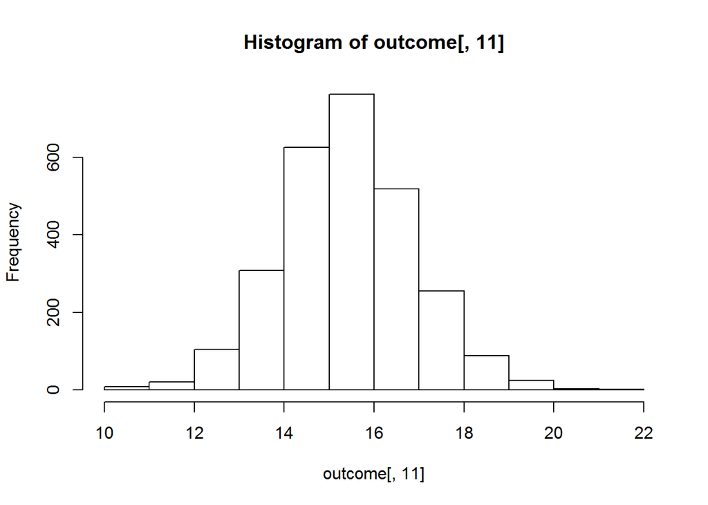

```r
## You may get a warning about NAs being introduced; that is okay
hist(outcome[, 11])
```

Because we originally read the data in as character (by specifying ‘colClasses = “character”’ we need to coerce the column to be numeric. You may get a warning about NAs being introduced but that is okay.

**There is nothing to submit for this part.**

## 2 Finding the best hospital in a state

Write a function called best that take two arguments: the 2-character abbreviated name of a state and an outcome name. The function reads the *outcome-of-care-measures.csv* file and returns a character vector with the name of the hospital that has the best (i.e. lowest) 30-day mortality for the specified outcome in that state. The hospital name is the name provided in the ‘Hospital.Name’ variable. The outcomes can be one of “heart attack”, “heart failure”, or “pneumonia”. Hospitals that do not have data on a particular outcome should be excluded from the set of hospitals when deciding the rankings.

**Handling ties.** If there is a tie for the best hospital for a given outcome, then the hospital names should be sorted in alphabetical order and the first hospital in that set should be chosen (i.e. if hospitals “b”, “c”, and “f” are tied for best, then hospital “b” should be returned).

The function should use the following template.

```r
best <- function(state = as.character(), outcome = as.character()) {
     ## Read outcome data & Check that state and outcome are valid
     setwd("~/R/Coursera/R Programming/Assignments/3_Hospital Quality/rprog-data-ProgAssignment3-data")
     data <- read.csv("outcome-of-care-measures.csv", colClasses = "character")

     data$State <- as.factor(data$State)
     State_lev <- levels(data$State)
     if (state %in% State_lev == F) stop("invalid state")

     Outcome_lev <- c("heart attack", "heart failure", "pneumonia")
     if (outcome %in% Outcome_lev == F) stop("invalid outcome")

     options(warn=-1)
     data$Hospital.30.Day.Death..Mortality..Rates.from.Heart.Attack <- as.numeric(data$Hospital.30.Day.Death..Mortality..Rates.from.Heart.Attack)
     data$Hospital.30.Day.Death..Mortality..Rates.from.Heart.Failure <- as.numeric(data$Hospital.30.Day.Death..Mortality..Rates.from.Heart.Failure)
     data$Hospital.30.Day.Death..Mortality..Rates.from.Pneumonia <- as.numeric(data$Hospital.30.Day.Death..Mortality..Rates.from.Pneumonia)
     options(warn=0)


     if (outcome == "heart attack") {
                    data_sub <- subset(data, State == state, select = c(
                         Hospital.Name,
                         Hospital.30.Day.Death..Mortality..Rates.from.Heart.Attack))
     } else {

     if (outcome == "heart failure") {
                    data_sub <- subset(data, State == state, select = c(
                         Hospital.Name,
                         Hospital.30.Day.Death..Mortality..Rates.from.Heart.Failure))
     } else {

     if (outcome == "pneumonia") {
                    data_sub <- subset(data, State == state, select = c(
                         Hospital.Name,
                         Hospital.30.Day.Death..Mortality..Rates.from.Pneumonia))
     }}}

     ## Return hospital name in that state with lowest 30-day death rate

     result <- data_sub$Hospital.Name[which.min(data_sub[,2])]
     sort(result)
}
```

The function should check the validity of its arguments. If an invalid state value is passed to best, the function should throw an error via the stop function with the exact message “invalid state”. If an invalid outcome value is passed to best, the function should throw an error via the stop function with the exact message “invalid outcome”.

Here is some sample output from the function.

```r
source("best.R")
best("TX", "heart attack")
```

```
## [1] "CYPRESS FAIRBANKS MEDICAL CENTER"
```

**[1] “CYPRESS FAIRBANKS MEDICAL CENTER”**

```r
best("TX", "heart failure")
```

```
## [1] "FORT DUNCAN MEDICAL CENTER"
```

**[1] “FORT DUNCAN MEDICAL CENTER”**

```r
best("MD", "heart attack")
```

```
## [1] "JOHNS HOPKINS HOSPITAL, THE"
```

**[1] “JOHNS HOPKINS HOSPITAL, THE”**

```r
best("MD", "pneumonia")
```

```
## [1] "GREATER BALTIMORE MEDICAL CENTER"
```

**[1] “GREATER BALTIMORE MEDICAL CENTER”**

```r
best("BB", "heart attack")
```

```
## Error: invalid state
```

**Error in best(“BB”, “heart attack”) : invalid state**

```r
best("NY", "hert attack")
```

```
## Error: invalid outcome
```

**Error in best(“NY”, “hert attack”) : invalid outcome**

Save your code for this function to a file named best.R.

Use the submit script provided to submit your solution to this part. There are 3 tests that need to be passed for this part of the assignment.

## 3 Ranking hospitals by outcome in a state

Write a function called ‘rankhospital’ that takes three arguments: the 2-character abbreviated name of a state (‘state’), an outcome (‘outcome’), and the ranking of a hospital in that state for that outcome (‘num’). The function reads the ‘outcome-of-care-measures.csv’ file and returns a character vector with the name of the hospital that has the ranking specified by the num argument. For example, the call

‘rankhospital(“MD”, “heart failure”, 5)’

would return a character vector containing the name of the hospital with the 5th lowest 30-day death rate for heart failure. The ‘num’ argument can take values “best”, “worst”, or an integer indicating the ranking (smaller numbers are better). If the number given by ‘num’ is larger than the number of hospitals in that state, then the function should return ‘NA’. Hospitals that do not have data on a particular outcome should be excluded from the set of hospitals when deciding the rankings.

The function should use the following template.

```r
rankhospital <- function(state, outcome, num = "best") {

     ## Read outcome data & Check that state and outcome are valid
     setwd("~/R/Coursera/R Programming/Assignments/3_Hospital Quality/rprog-data-ProgAssignment3-data")
     data <- read.csv("outcome-of-care-measures.csv", colClasses = "character")

     data$State <- as.factor(data$State)
     State_lev <- levels(data$State)
     if (state %in% State_lev == F) stop("invalid state")

     Outcome_lev <- c("heart attack", "heart failure", "pneumonia")
     if (outcome %in% Outcome_lev == F) stop("invalid outcome")

     options(warn=-1)
     data$Hospital.30.Day.Death..Mortality..Rates.from.Heart.Attack <- as.numeric(data$Hospital.30.Day.Death..Mortality..Rates.from.Heart.Attack)
     data$Hospital.30.Day.Death..Mortality..Rates.from.Heart.Failure <- as.numeric(data$Hospital.30.Day.Death..Mortality..Rates.from.Heart.Failure)
     data$Hospital.30.Day.Death..Mortality..Rates.from.Pneumonia <- as.numeric(data$Hospital.30.Day.Death..Mortality..Rates.from.Pneumonia)
     options(warn=0)


     if (outcome == "heart attack") {
          data_sub <- subset(data, State == state, select = c(
               Hospital.Name,
               Hospital.30.Day.Death..Mortality..Rates.from.Heart.Attack))
          data_sub <- data_sub[order(data_sub$Hospital.30.Day.Death..Mortality..Rates.from.Heart.Attack,
                                     data_sub$Hospital.Name, na.last = NA),]

     } else {

     if (outcome == "heart failure") {
          data_sub <- subset(data, State == state, select = c(
               Hospital.Name,
               Hospital.30.Day.Death..Mortality..Rates.from.Heart.Failure))
          data_sub <- data_sub[order(data_sub$Hospital.30.Day.Death..Mortality..Rates.from.Heart.Failure,
                                     data_sub$Hospital.Name, na.last = NA),]

     } else {

     if (outcome == "pneumonia") {
          data_sub <- subset(data, State == state, select = c(
               Hospital.Name,
               Hospital.30.Day.Death..Mortality..Rates.from.Pneumonia))
          data_sub <- data_sub[order(data_sub$Hospital.30.Day.Death..Mortality..Rates.from.Pneumonia,
                                     data_sub$Hospital.Name, na.last = NA),]
     }}}

     ## Return hospital name in that state with the given rank 30-day death rate

     if (num == "best") {
          data_sub[1, 1]

     } else {

     if (num == "worst") {
          data_sub[nrow(data_sub), 1]

     } else {

     if (num > nrow(data_sub)) {
          print(NA)

     } else {
          data_sub[num, 1]}

     }}

}
```

The function should check the validity of its arguments. If an invalid state value is passed to best, the function should throw an error via the stop function with the exact message “invalid state”. If an invalid outcome value is passed to best, the function should throw an error via the stop function with the exact message “invalid outcome”. Here is some sample output from the function.

```r
source("rankhospital.R")
rankhospital("TX", "heart failure", 4)
```

```
## [1] "DETAR HOSPITAL NAVARRO"
```

**[1] “DETAR HOSPITAL NAVARRO”**

```r
rankhospital("MD", "heart attack", "worst")
```

```
## [1] "HARFORD MEMORIAL HOSPITAL"
```

**[1] “HARFORD MEMORIAL HOSPITAL”**

```r
rankhospital("MN", "heart attack", 5000)
```

```
## [1] NA
```

**[1] NA**

Save your code for this function to a file named rankhospital.R.

Use the submit script provided to submit your solution to this part. There are 4 tests that need to be passed for this part of the assignment.

## 4 Ranking hospitals in all states

Write a function called ‘rankall’ that takes two arguments: an outcome name (‘outcome’) and a hospital ranking (‘num’). The function reads the ‘outcome-of-care-measures.csv’ file and returns a 2-column data frame containing the hospital in each state that has the ranking specified in num. For example the function call ‘rankall(“heart attack”, “best”)’ would return a data frame containing the names of the hospitals that are the best in their respective states for 30-day heart attack death rates. The function should return a value for every state (some may be ‘NA’). The first column in the data frame is named ‘hospital’, which contains the hospital name, and the second column is named ‘state’, which contains the 2-character abbreviation for the state name. Hospitals that do not have data on a particular outcome should be excluded from the set of hospitals when deciding the rankings.

**Handling ties.** The ‘rankall’ function should handle ties in the 30-day mortality rates in the same way that the ‘rankhospital’ function handles ties.

The function should use the following template.

```r
rankall <- function(outcome = as.character(), num = "best") {
     ## Read outcome data
     # hospital name is set as character var. by default
     setwd("~/R/Coursera/R Programming/Assignments/3_Hospital Quality/rprog-data-ProgAssignment3-data")
     data <- read.csv("outcome-of-care-measures.csv", colClasses = "character")

     # state is set as factor var.
     data$State <- as.factor(data$State)

     # outcome vars. are set as numeric (warning about NAs turned off and on again later)
     options(warn=-1)
     data$Hospital.30.Day.Death..Mortality..Rates.from.Heart.Attack <- as.numeric(data$Hospital.30.Day.Death..Mortality..Rates.from.Heart.Attack)
     data$Hospital.30.Day.Death..Mortality..Rates.from.Heart.Failure <- as.numeric(data$Hospital.30.Day.Death..Mortality..Rates.from.Heart.Failure)
     data$Hospital.30.Day.Death..Mortality..Rates.from.Pneumonia <- as.numeric(data$Hospital.30.Day.Death..Mortality..Rates.from.Pneumonia)
     options(warn=0)

     # Maximum amount of hospitals per state
     max <- max(table(data$State))

     ## Check that outcome input is valid
     Outcome_lev <- c("heart attack", "heart failure", "pneumonia")
     if (outcome %in% Outcome_lev == F) stop("invalid outcome")

     ## For each state, find the hospital of the given rank

     if (outcome == "heart attack") {
          data_sub <- subset(data, select = c(
               State,
               Hospital.Name,
               Hospital.30.Day.Death..Mortality..Rates.from.Heart.Attack))
          data_sub <- data_sub[order(data_sub$State,
                                     data_sub$Hospital.30.Day.Death..Mortality..Rates.from.Heart.Attack,
                                     data_sub$Hospital.Name, na.last = NA),]
     } else {

     if (outcome == "heart failure") {
          data_sub <- subset(data, select = c(
               State,
               Hospital.Name,
               Hospital.30.Day.Death..Mortality..Rates.from.Heart.Failure))
          data_sub <- data_sub[order(data_sub$State,
                                     data_sub$Hospital.30.Day.Death..Mortality..Rates.from.Heart.Failure,
                                     data_sub$Hospital.Name, na.last = NA),]
     } else {

     if (outcome == "pneumonia") {
          data_sub <- subset(data, select = c(
               State,
               Hospital.Name,
               Hospital.30.Day.Death..Mortality..Rates.from.Pneumonia))
          data_sub <- data_sub[order(data_sub$State,
                                     data_sub$Hospital.30.Day.Death..Mortality..Rates.from.Pneumonia,
                                     data_sub$Hospital.Name, na.last = NA),]
          }

     }}

     if (num == "best") {
          hospital <- tapply(data_sub$Hospital.Name,
                             data_sub$State,
                             FUN = function(x) {x[1]}, simplify = F)

     } else {

          if (num == "worst") {
          hospital <- tapply(data_sub$Hospital.Name,
                 data_sub$State,
                 FUN = function(x) {x[length(x)]}, simplify = F)

     } else {

               if (num > max) {
                    print(NA)

               } else {
                         hospital <- tapply(data_sub$Hospital.Name,
                                data_sub$State,
                                FUN = function(x) {x[num]},
                                simplify = F)
               }
     }}

     ## Return a data frame with the hospital names and the (abbreviated) state name

     state <- dimnames(hospital)[[1]]
     hospital <- unlist(hospital)

     Result <- data.frame()
     Result <- cbind(hospital, state)
     Result <- as.data.frame(Result)
     Result
}
```

**NOTE:** For the purpose of this part of the assignment (and for efficiency), your function should NOT call the ‘rankhospital’ function from the previous section.

The function should check the validity of its arguments. If an invalid outcome value is passed to ‘rankall’, the function should throw an error via the ‘stop’ function with the exact message “invalid outcome”. The ‘num’ variable can take values “best”, “worst”, or an integer indicating the ranking (smaller numbers are better). If the number given by ‘num’ is larger than the number of hospitals in that state, then the function should return ‘NA’.

Here is some sample output from the function.

```r
source("rankall.R")
head(rankall("heart attack", 20), 3)
```

```
##                             hospital state
## AK                              <NA>    AK
## AL    D W MCMILLAN MEMORIAL HOSPITAL    AL
## AR ARKANSAS METHODIST MEDICAL CENTER    AR
```

[output not shown]

```r
tail(rankall("pneumonia", "worst"), 3)
```

```
##                                      hospital state
## WI MAYO CLINIC HEALTH SYSTEM - NORTHLAND, INC    WI
## WV                     PLATEAU MEDICAL CENTER    WV
## WY           NORTH BIG HORN HOSPITAL DISTRICT    WY
```

[output not shown]

```r
tail(rankall("heart failure"), 3)
```

```
##                          hospital state
## WI AURORA ST LUKES MEDICAL CENTER    WI
## WV      FAIRMONT GENERAL HOSPITAL    WV
## WY     CHEYENNE VA MEDICAL CENTER    WY
```

[output not shown]

Save your code for this function to a fle named ‘rankall.R’.

Use the submit script provided to submit your solution to this part. There are 3 tests that need to be passed for this part of the assignment.